# Single-cell analysis: LiFi 1.0 (LED) vs LiFi 2.0 (VCSEL)

This notebook implements a single-cell analysis for the comparative study between LiFi 1.0 and LiFi 2.0. It is divided into two stages because each one answers a different question.

**Phase 1** investigates how the channel models differ when both technologies operate under the same conditions by keeping the transmit power identical.

**Phase 2** investigates how both technologies perform under realistic operating conditions. In this case, each transmitter operates within its own practical constraints, allowing the impact of illumination and eye-safety requirements to be evaluated.

Every paper cited in this notebook is stored in the `sources/` folder.

### References

| Key | Paper | Used for |
| --- | --- | --- |
| `[RIS-VLC]` | Resource Allocation Exploiting Reflective Surfaces to Minimize the Outage Probability in VLC | LiFi 1.0 Lambertian LOS channel — eq. (1); optical power → illuminance — eq. (25); SNR — eq. (12); FoV coverage radius — eq. (11); parameters ($K_{e/v}$, FoV, $B$, $N_0$) — Table III |
| `[VCSEL-Precoding]` | Safi et al., Energy-Efficient Precoding for Dense VCSEL-Based OWC Systems Under a Cooperative Broadcast Model | LiFi 2.0 single-VCSEL Gaussian-beam channel — eqs. (2)–(8); parameters ($w_0$, $\lambda$, $n$, $A_{PD}$, $\rho$, $B$) — Table I |
| `[Capacity-Bound]` | Wang et al., Tight Bounds on Channel Capacity for Dimmable Visible Light Communications | Achievable-rate lower bound for both technologies — eq. (37) (cited as [39] in `[RIS-VLC]` and [31] in `[VCSEL-Precoding]`) |
| `[Eye-Safety]` | Soltani et al., Safety Analysis for Laser-Based Optical Wireless Communications: A Tutorial | Max eye-safe CW power of a single-mode VCSEL — Algorithm 1, eq. (36), divergence eq. (8); IEC 60825-1:2014 near-IR MPE — Table 4 |
| `[VCSEL-70Gbps]` | Kazemi et al. 2025, Achieving 70 Gb/s Over a VCSEL-Based Optical Wireless Link Using a Multi-Mode Fiber-Coupled Receiver | Experimental single-VCSEL operating power (~5 mW, 940 nm) as an eye-safety cross-check — Table I / abstract |

## 0. Common scenario

Everything here stays the same across both phases and both technologies: the room, the ceiling/desk height, the transmitter position, the photodetector, and the receiver grid. The only parameters that change later on are the ones related to channel model (Phase 1) and the transmit power (Phase 2).

```python
import numpy as np
import matplotlib.pyplot as plt

# room and tx/rx geometry, shared by every cell in the code below

ROOM_X, ROOM_Y = 5.0, 5.0 # room floor size [m] (typical attocell footprint)
TX_HEIGHT = 3.0 # tx height, mounted on the ceiling [m]
RX_HEIGHT = 1.0 # rx height, desk level [m]
TX_POS = np.array([ROOM_X / 2, ROOM_Y / 2, TX_HEIGHT]) # tx at the center of the ceiling
dz = TX_HEIGHT - RX_HEIGHT # vertical tx-rx separation [m], used everywhere below

APD = 1e-4 # photodetector active area A_PD [m^2] = 1 cm^2 ([RIS-VLC] Table III / [VCSEL-Precoding] Table I)
RHO = 1.0 # photodetector responsivity rho [A/W], same in both papers (see wavelength note in Phase 2)

# receiver grid: N x N points covering the whole floor
N = 300
xs = np.linspace(0, ROOM_X, N)
ys = np.linspace(0, ROOM_Y, N)
X, Y = np.meshgrid(xs, ys)

r0 = np.sqrt((X - TX_POS[0])**2 + (Y - TX_POS[1])**2) # horizontal distance from tx to each rx point [m]
d3d = np.sqrt(r0**2 + dz**2) # straight-line tx-rx distance [m]
theta = np.arctan2(r0, dz) # irradiance/incidence angle seen from tx [rad]

print(f"Room {ROOM_X:.0f}x{ROOM_Y:.0f}x{TX_HEIGHT:.0f} m")
print(f"Tx-Rx vertical separation = {dz:.1f} m")
```

```
Room 5x5x3 m
Tx-Rx vertical separation = 2.0 m
```

## Phase 1 — Ideal single-cell analysis (channel comparison)

In this phase, everything is kept constant except the channel model: same room, same Tx/Rx geometry, same $A_{PD}$ and $\rho$, same treatment of the receiver FoV, and both transmitters send the same normalization power, $P_{tx} = 1\,\text{W}$

The 1 W value is set just so both technologies are compared under the exact same conditions. The goal of this first analysis is only to see how the Lambertian and the Gaussian-beam models differ, without power getting in the way.

One thing to decide: how to treat the receiver field of view (FoV) in the VCSEL model

- The `[VCSEL-Precoding]` paper does not include an angular cut-off in their channel equation, the optical concentrator gain they use corresponds to the classical Kahn-Barry model, where the concentrator gain becomes zero outside the receiver FoV. Since the FoV is a property of the receiver rather than the transmitter, the same angular limitation has been applied to both technologies.
- This option has been left as a configurable parameter in the implementation in order to evaluate how sensitive the results are to this assumption.

```python
# LiFi 1.0: LED, Lambertian, LOS only

# Channel model [RIS-VLC] eq. (1):  H_LoS = (m+1)*A_PD/(2*pi*d^2) * cos^m(phi) * cos(psi),  0 <= psi <= Psi
# Lambertian order  [RIS-VLC] eq. (1):  m = -1 / log2(cos(phi_1/2))

PHI_HALF_DEG = 80.0 # LED half-power semiangle [deg]
FOV_DEG = 40.0 # rx field-of-view semiangle Psi [deg] (Table III lists 30/40/50, I use 40)

m_led = -1.0 / np.log2(np.cos(np.deg2rad(PHI_HALF_DEG))) # Lambertian order
FOV = np.deg2rad(FOV_DEG)

# emitter points down and rx points up => irradiance angle phi = incidence angle psi = theta
H_led = (m_led + 1) * APD / (2 * np.pi * d3d**2) * np.cos(theta)**m_led * np.cos(theta) # LOS Lambertian gain from [RIS-VLC] eq. (1)
H_led = np.where(theta <= FOV, H_led, 0.0)  # zero outside the rx fov

# LiFi 2.0: single VCSEL, Gaussian beam ([VCSEL-Precoding], Safi et al., eqs. (2)-(8))
W0 = 0.45e-6 # beam waist w0 at the VCSEL aperture [m], [VCSEL-Precoding] Table I
LAMBDA = 950e-9 # VCSEL wavelength lambda [m], [VCSEL-Precoding] Table I

N_LENS = 1.5 # rx concentrator lens refractive index n, [VCSEL-Precoding] eq. (8)
THETA_R_DEG = 60.0 # rx fov semiangle for the VCSEL, from Fig. 4 (they show 60/90 deg); 60 deg chosen here

APPLY_VCSEL_FOV_CUTOFF = True  # to add the receiver-FoV cut-off (not in the paper bc fov is a receiver property)

theta_r = np.deg2rad(THETA_R_DEG)
G_lens = N_LENS**2 / np.sin(theta_r)**2 # non-imaging concentrator gain G, [VCSEL-Precoding] eq. (8)
zR = np.pi * W0**2 / LAMBDA # Rayleigh range of the beam [m]

wz = W0 * np.sqrt(1 + (d3d / zR)**2) # beam radius at distance d3d [m]
# w(z), [VCSEL-Precoding] eq. (6) (paper uses the full tx-rx distance)

Z_irr = 2 / (np.pi * wz**2) * np.exp(-2 * r0**2 / wz**2) # Gaussian irradiance profile, [VCSEL-Precoding] eq. (7)

H_vcsel = Z_irr * APD * G_lens # LOS gain for the VCSEL channel, [VCSEL-Precoding] eq. (8)
if APPLY_VCSEL_FOV_CUTOFF:
    H_vcsel = np.where(theta <= theta_r, H_vcsel, 0.0)

print(f"m_led = {m_led:.3f}")
print(f"theta_r={THETA_R_DEG:.0f} deg -> G_lens = {G_lens:.3f}")
print(f"LED - receiver FoV footprint radius on the desk plane: {dz*np.tan(FOV):.2f} m")
print(f"VCSEL - receiver FoV footprint radius on the desk plane: {dz*np.tan(theta_r):.2f} m "
      f"(cutoff {'applied' if APPLY_VCSEL_FOV_CUTOFF else 'not applied'})")
```

```
m_led = 0.396
theta_r=60 deg -> G_lens = 3.000
LED - receiver FoV footprint radius on the desk plane: 1.68 m
VCSEL - receiver FoV footprint radius on the desk plane: 3.46 m (cutoff applied)
```

### Channel-gain maps

Just the shape of each channel, independent of power.

- A receiver only "sees" the transmitter while the incidence angle stays within its field-of-view (FoV) semiangle $\Psi_c$. On the desk plane this maps to a coverage *disk* of radius

$$r_\text{FoV} = \Delta z\,\tan(\Psi_c),$$

Outside its disk the non-imaging concentrator gain is zero, so $H=0$ and $10\log_{10}H\to-\infty$.

**Notes from the maps**

- Outside the FoV disk the gain is exactly zero (gain $\to-\infty$ in dB).
- The cut-off is caused by the receiver FoV, so it applies to both technologies. For the LED because its disk (1.68 m) covers only 35 % approximately of this 5 m room which is very clear; the VCSEL disk (3.46 m) is larger than the room, so its cut-off only clips the four corners and can barely be noticed.

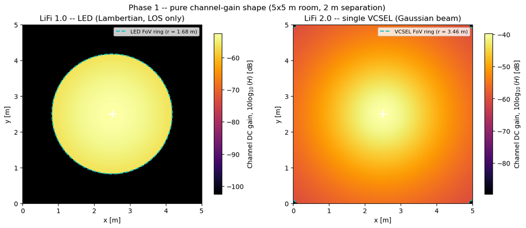

```python
def to_dB(H):
    # channel gain in dB
    with np.errstate(divide="ignore"):
        return np.where(H > 0, 10 * np.log10(H), np.nan)

H_led_dB = to_dB(H_led)
H_vcsel_dB = to_dB(H_vcsel)

# radio que ve el receptor = dz * tan(FoV semiangle)
r_fov_led   = dz * np.tan(FOV)
r_fov_vcsel = dz * np.tan(theta_r)

cmap = plt.cm.inferno.copy()
cmap.set_bad("black")

fig, axes = plt.subplots(1, 2, figsize=(11.5, 4.8), constrained_layout=True)
maps = [(H_led_dB,   "LiFi 1.0 -- LED (Lambertian, LOS only)",   r_fov_led,   "LED FoV"),
        (H_vcsel_dB, "LiFi 2.0 -- single VCSEL (Gaussian beam)", r_fov_vcsel, "VCSEL FoV")]
th = np.linspace(0, 2 * np.pi, 200)
for ax, (H_dB, title, r_fov, lbl) in zip(axes, maps):
    # per-panel 40 dB scale so each channel's own structure is visible
    vmax = np.nanmax(H_dB)
    vmin = vmax - 50  # keep 50 dB of dynamic range per panel
    im = ax.pcolormesh(X, Y, H_dB, shading="auto", cmap=cmap, vmin=vmin, vmax=vmax)
    ax.plot(TX_POS[0] + r_fov * np.cos(th), TX_POS[1] + r_fov * np.sin(th),
            "c--", lw=1.6, label=f"{lbl} ring (r = {r_fov:.2f} m)")
    ax.plot(*TX_POS[:2], "w+", markersize=12, mew=2)
    ax.set_xlabel("x [m]")
    ax.set_ylabel("y [m]")
    ax.set_title(title)
    ax.set_aspect("equal")
    ax.set_xlim(0, ROOM_X)
    ax.set_ylim(0, ROOM_Y)
    ax.legend(loc="upper right", fontsize=8)
    fig.colorbar(im, ax=ax, label=r"Channel DC gain, $10\log_{10}(H)$ [dB]", shrink=0.9)
fig.suptitle(f"Phase 1 -- pure channel-gain shape ({ROOM_X:.0f}x{ROOM_Y:.0f} m room, {dz:.0f} m separation)")
plt.show()
```

### Radial profile

Same gain, but sliced along a straight line going outward from directly below the Tx, so the LED and VCSEL shapes are easier to compare.

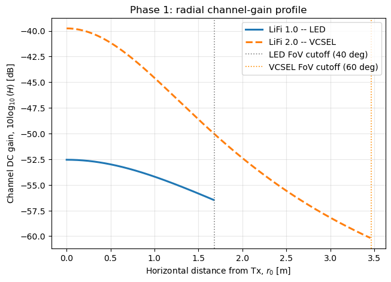

```python
r0_line = np.linspace(1e-3, np.hypot(ROOM_X, ROOM_Y) / 2, 400)  # horizontal distance samples [m]
d_line = np.sqrt(r0_line**2 + dz**2)   # straight-line tx-rx distance along that line [m]
th_line = np.arctan2(r0_line, dz)      # incidence angle along that line [rad]

Hl_line = (m_led + 1) * APD / (2 * np.pi * d_line**2) * np.cos(th_line)**m_led * np.cos(th_line)  # same LED formula as before
Hl_line = np.where(th_line <= FOV, Hl_line, np.nan)  # NaN outside FoV so it just doesn't plot

wz_line = W0 * np.sqrt(1 + (d_line / zR)**2)  # VCSEL beam radius along the line [m]
Hv_line = (2 / (np.pi * wz_line**2) * np.exp(-2 * r0_line**2 / wz_line**2)) * APD * G_lens  # same VCSEL formula as before
if APPLY_VCSEL_FOV_CUTOFF:
    Hv_line = np.where(th_line <= theta_r, Hv_line, np.nan)

fig, ax = plt.subplots(figsize=(7.2, 5))
ax.plot(r0_line, 10 * np.log10(Hl_line), lw=2.2, label="LiFi 1.0 -- LED")
ax.plot(r0_line, 10 * np.log10(Hv_line), lw=2.2, ls="--", label="LiFi 2.0 -- VCSEL")
ax.axvline(dz * np.tan(FOV), color="gray", ls=":", lw=1.2, label=f"LED FoV cutoff ({FOV_DEG:.0f} deg)")
if APPLY_VCSEL_FOV_CUTOFF:
    ax.axvline(dz * np.tan(theta_r), color="darkorange", ls=":", lw=1.2, label=f"VCSEL FoV cutoff ({THETA_R_DEG:.0f} deg)")
ax.set_xlabel(r"Horizontal distance from Tx, $r_0$ [m]")
ax.set_ylabel(r"Channel DC gain, $10\log_{10}(H)$ [dB]")
ax.set_title("Phase 1: radial channel-gain profile")
ax.legend()
ax.grid(alpha=.3)
plt.show()
```

### Received power, SNR and achievable rate at the normalization power

The achievable rate is computed using

$$ R=\frac{B}{2}\log_2\left(1+\frac{e}{2\pi}\mathrm{SNR}\right), $$

which is the lower bound commonly adopted for IM/DD systems, from `[Capacity-Bound]`. Both `[RIS-VLC]` and `[VCSEL-Precoding]` use this expression instead of the classical Shannon capacity because optical wireless communication uses intensity modulation with non-negative signals, making the standard Shannon expression less appropriate.

For the noise, we assume the same PSD $N_0$ for both technologies. The `[RIS-VLC]` paper gives a value for $N_0$, `[VCSEL-Precoding]` doesn't, so I reuse the same one for the VCSEL under the assumption that the receiver itself doesn't change. This way any difference in the results comes from the transmitter and the channel, not from an arbitrary noise choice. Even with the same $N_0$, the total noise power still differs between the two because the bandwidth is different (20 MHz for LiFi 1.0, 2 GHz for LiFi 2.0).

This is a simplification since a GHz-class receiver wouldn't really share the exact same noise characteristics as one built for a few tens of MHz; but keeping $N_0$ fixed allows to isolate the effect of the propagation model, which is the actual point of this first part.

```python
N0 = 2.5e-20   # noise PSD N0 [W/Hz], [RIS-VLC] (reused for LiFi 2.0)
B1 = 20e6      # LiFi 1.0 bandwidth [Hz], [RIS-VLC] Table III
B2 = 2e9       # LiFi 2.0 bandwidth [Hz], [VCSEL-Precoding] Table I
K_BOUND = np.e / (2 * np.pi)  # constant e/(2*pi) in the rate bound, [Capacity-Bound] eq. (37)

def snr_rate(Ptx_led, Ptx_vcsel):
    Pr_led = Ptx_led * H_led # received optical power, LED [W]
    Pr_vcsel = Ptx_vcsel * H_vcsel # received optical power, VCSEL [W]
    SNR_led = (RHO * Pr_led)**2 / (N0 * B1)
    SNR_vcsel = (RHO * Pr_vcsel)**2 / (N0 * B2)
    # achievable-rate lower bound R = (B/2)*log2(1 + (e/2pi)*SNR), [Capacity-Bound] eq. (37)
    R_led = 0.5 * B1 * np.log2(1 + K_BOUND * SNR_led)   # [bit/s]
    R_vcsel = 0.5 * B2 * np.log2(1 + K_BOUND * SNR_vcsel) # [bit/s]
    return Pr_led, Pr_vcsel, SNR_led, SNR_vcsel, R_led, R_vcsel

PTX_NORM = 1.0  # normalization power for Phase 1 [W], same for both transmitters
Pr_led1, Pr_vcsel1, SNR_led1, SNR_vcsel1, R_led1, R_vcsel1 = snr_rate(PTX_NORM, PTX_NORM)

print(f"Phase 1 @ Ptx = {PTX_NORM:.0f} W (both):")
print(f"  LiFi 1.0: peak Pr={np.nanmax(Pr_led1)*1e3:.3f} mW, peak SNR={10*np.log10(np.nanmax(SNR_led1)):.1f} dB "
      f", peak rate={np.nanmax(R_led1)/1e6:.1f} Mbit/s")
print(f"  LiFi 2.0: peak Pr={np.nanmax(Pr_vcsel1)*1e3:.3f} mW, peak SNR={10*np.log10(np.nanmax(SNR_vcsel1)):.1f} dB "
      f", peak rate={np.nanmax(R_vcsel1)/1e6:.1f} Mbit/s")
```

```
Phase 1 @ Ptx = 1 W (both):
  LiFi 1.0: peak Pr=0.006 mW, peak SNR=17.9 dB , peak rate=47.9 Mbit/s
  LiFi 2.0: peak Pr=0.106 mW, peak SNR=23.5 dB , peak rate=6610.3 Mbit/s
```

### Coverage vs. SNR threshold

Instead of picking one SNR threshold and reporting a single coverage number, I sweep the threshold and plot the whole curve to show a lot more about how the two channels behave

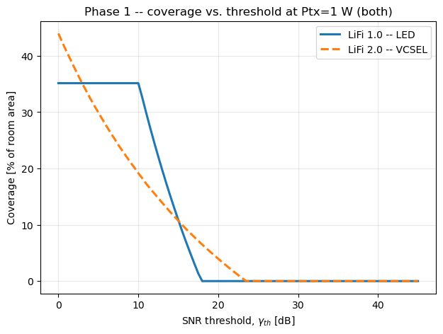

```python
th_range_dB = np.linspace(0, 45, 91)  # SNR thresholds to sweep [dB]
cov_led_curve, cov_vcsel_curve = [], []
for th_dB in th_range_dB:
    g = 10**(th_dB / 10)  # threshold converted to linear scale
    cov_led_curve.append(100 * np.mean(SNR_led1 >= g))      # % of room area above threshold, LED
    cov_vcsel_curve.append(100 * np.mean(SNR_vcsel1 >= g))  # % of room area above threshold, VCSEL

fig, ax = plt.subplots(figsize=(7.2, 5))
ax.plot(th_range_dB, cov_led_curve, lw=2.2, label="LiFi 1.0 -- LED")
ax.plot(th_range_dB, cov_vcsel_curve, lw=2.2, ls="--", label="LiFi 2.0 -- VCSEL")
ax.set_xlabel(r"SNR threshold, $\gamma_{th}$ [dB]")
ax.set_ylabel("Coverage [% of room area]")
ax.set_title(f"Phase 1 -- coverage vs. threshold at Ptx={PTX_NORM:.0f} W (both)")
ax.legend()
ax.grid(alpha=.3)
plt.show()
```

```python
# how much of each technology's own FoV disk is actually reached at Ptx=1W,


diff = np.array(cov_vcsel_curve) - np.array(cov_led_curve)
sign_changes = np.where(np.diff(np.sign(diff)) != 0)[0]

print("Crossing point(s) between the LED and VCSEL coverage-vs-threshold curves:")
for idx in sign_changes:
    th1, th2 = th_range_dB[idx], th_range_dB[idx + 1]
    d1, d2 = diff[idx], diff[idx + 1]
    th_cross = th1 - d1 * (th2 - th1) / (d2 - d1)
    print(f"  ~{th_cross:4.1f} dB  (LED~{cov_led_curve[idx]:.1f}%, VCSEL~{cov_vcsel_curve[idx]:.1f}%)")

fov_disk_led_pct = 100 * np.pi * (dz * np.tan(FOV))**2 / (ROOM_X * ROOM_Y)
_gx = np.linspace(-ROOM_X/2, ROOM_X/2, 1500)
_Xg, _Yg = np.meshgrid(_gx, _gx)
fov_disk_vcsel_pct = 100 * np.mean((_Xg**2 + _Yg**2) <= (dz * np.tan(theta_r))**2)

print(f"\nLED FoV-disk geometric max coverage: {fov_disk_led_pct:5.1f}% "
      f"(LED's curve above is essentially flat at this value for low thresholds)")
print(f"VCSEL FoV-disk geometric max coverage: {fov_disk_vcsel_pct:5.1f}% "
      f"(VCSEL's curve above never gets close to this at only Ptx=1 W)")
```

```
Crossing point(s) between the LED and VCSEL coverage-vs-threshold curves:
  ~ 3.0 dB  (LED~35.1%, VCSEL~36.4%)
  ~15.1 dB  (LED~10.9%, VCSEL~10.7%)
  ~23.5 dB  (LED~0.0%, VCSEL~0.5%)

LED FoV-disk geometric max coverage:  35.4% (LED's curve above is essentially flat at this value for low thresholds)
VCSEL FoV-disk geometric max coverage:  99.9% (VCSEL's curve above never gets close to this at only Ptx=1 W)
```

- At low thresholds, the LED curve flattens out. Just 1 W of power is more than enough to light up its entire light cone. Because it quickly hits its maximum geometric area, lowering the threshold any further won't add any more covered space.
- The VCSEL behaves differently. Its potential coverage area is huge (almost the size of the whole room). However, 1W of power isn't strong enough to provide a good signal across that entire space. As a result, its covered area keeps growing as the threshold gets easier, long after the LED has already maxed out.

The two curves cross each other

1. At the start: the VCSEL performs better near 0 dB because it is highly efficient right in the center of the beam
2. In the middle: the LED does better because the VCSEL's light intensity drops off much faster as you move away from the center
3. At the end: the VCSEL overtakes the LED at high thresholds, right before the LED runs out of signal strength and its coverage drops to zero

**Phase 1 Conclusion** Every difference in signal strength and coverage comes only from how the light travels (Lambertian vs. Gaussian) and the receiver setup. Since both transmitters use the exact same power, this first analysis only evaluates the light channel itself; it doesn't tell us yet which technology is more practical in the real world.

## Phase 2 — Realistic single-cell analysis

Here the question changes. Phase 1 asked "how do the channels compare", Phase 2 asks "what actually happens once each technology is limited by its own real constraints." So instead of the arbitrary 1 W for both, each transmitter now gets the power it would realistically use.

### LiFi 1.0 power: illuminance requirement

The LED power is obtained from an illuminance target: 500 lux, the standard EN 12464-1 value for office/reading tasks, and also the target used in the `[RIS-VLC]` reference paper (Sec. V). The same Lambertian model from Phase 1 is used, but now written in terms of illuminance instead of gain.

The $A_{PD}$ term cancels out because illuminance describes the light field itself, not any particular detector:

$$E_v(0) = K_{e/v}\cdot P_{tx}\cdot\frac{m+1}{2\pi d_z^2}\quad\Rightarrow\quad P_{tx}=\frac{E_{target}}{E_v(0)/P_{tx}}$$

The `[RIS-VLC]` paper's own optimized benchmark (Fig. 15) uses 4 LEDs together reaching 500 lux average in a 4x4x3 m room, with about 82-90 W total (roughly 20-22 W per LED). The isolated LED used in this analysis needs somewhat more than that per-LED figure, which makes sense as in their case four LEDs share the work of lighting the room, so one LED on its own has to work harder.

> Here the power is set so the illuminance directly below the Tx (the peak) equals 500 lux. EN 12464-1 and `[RIS-VLC]` define 500 lux as an average over the task area, so this is a simplification: the room-average illuminance of this single LED is below 500 lux --> $P_{tx}$ here is a lower bound

```python
KE_V = 280.0          # luminous efficacy K_e/v [lm/W], [RIS-VLC] Table III
E_TARGET_LUX = 500.0  # illuminance target [lux], EN 12464-1 office value ([RIS-VLC] Sec. V)

# Illuminance from optical power, [RIS-VLC] eq. (25):  E_v = (K_e/v / A_PD) * P * H_LoS

# directly below tx: H_LoS(0) = (m+1)*A_PD/(2*pi*dz^2), so A_PD cancels:
E_per_watt_boresight = KE_V * (m_led + 1) / (2 * np.pi * dz**2)  # lux produced per watt, directly below the tx
PTX_LED_REALISTIC = E_TARGET_LUX / E_per_watt_boresight          # LED power needed to hit the target [W]
print(f"LiFi 1.0 realistic power (single LED, {E_TARGET_LUX:.0f} lux target): {PTX_LED_REALISTIC:.1f} W")
```

```
LiFi 1.0 realistic power (single LED, 500 lux target): 32.2 W
```

### LiFi 2.0 power: eye safety (IEC 60825-1:2014)

For the VCSEL, the transmit power is limited by eye-safety requirements.

Unlike LEDs, VCSELs are laser sources, meaning that the maximum optical power of a single emitter is constrained by the IEC 60825-1 laser safety standard. Consequently, a single VCSEL cannot operate at the same optical power as a LED.

To obtain a realistic value, the maximum eye-safe power is estimated following the methodology presented in `[Eye-Safety]` (Soltani et al.). This value is also compared with experimentally reported operating powers found in the literature (`[VCSEL-70Gbps]`), confirming that practical single-mode VCSELs typically operate in the milliwatt range.

### Limitation of the eye-safety power estimation

The eye-safety limit depends strongly on the assumed beam waist $w_0 = 0.45\ \mu m$ (`[VCSEL-Precoding]` Table I), which is smaller than the VCSEL's wavelength $\lambda = 950\ nm$. The Gaussian-beam model requires $w_0 \gg \lambda$, so this value isn't fully valid here.

Such a small $w_0$ gives an unrealistically large divergence, $\theta \approx \lambda/(\pi w_0) \approx 38º$ half-angle, wider than a real VCSEL beam. This makes the model beam spread and lose intensity faster than a real device would, so less power is assumed to reach the eye, which pushes the estimated safe power up: $P_{tx,max} = 224.9\ mW$, about 45x above the $5\ mW$ experimentally reported in `[VCSEL-70Gbps]`.

> A more realistic waist (e.g. $w_0 \approx 5\ \mu m$) would bring the estimate down toward that range.

This doesn't change the conclusion: a single VCSEL is still strongly power-limited compared with an LED, but 224.9 mW should be read as an optimistic ceiling, not a practical limit.

```python
def mpe_point_long_exposure(lam_nm):
    # IEC 60825-1 point-source MPE, near-IR, long exposure (t_ex > 10 s)
    # [Eye-Safety] Table 4:  MPE = 10 * C4 * C7 [W/m^2];  C4 = 10^(0.002(lam-700));  C7 = 1 for lam < 1150 nm
    C4 = 10**(0.002 * (lam_nm - 700))
    C7 = 1.0 if lam_nm < 1150 else 10**(0.018 * (lam_nm - 1150))
    return 10 * C4 * C7  # MPE [W/m^2]

assert abs(mpe_point_long_exposure(850) - 19.95) < 0.1  # [Eye-Safety]: ~20 W/m^2 at 850 nm (matches the tutorial)
MPE_950 = mpe_point_long_exposure(950)

def eye_safe_ptx(w0, lam, rp=3.5e-3):
    # max eye-safe CW power for a single-mode Gaussian VCSEL beam, [Eye-Safety] Algorithm 1 + eq. (36)
    # w0: beam waist [m], lam: wavelength [m], rp: worst-case dilated pupil radius [m]
    # rp = 3.5 mm -> 7 mm limiting aperture ([Eye-Safety] Sec. II-D)

    zR_ = np.pi * w0**2 / lam       # Rayleigh range, [VCSEL-Precoding] eq. (2) / [Eye-Safety] eq. (5)
    theta_div = lam / (np.pi * w0)  # beam divergence half-angle, [Eye-Safety] eq. (8)
    d86 = (np.pi * w0 / lam) * np.sqrt(-2 * rp**2 / np.log(1 - 0.86))  # distance where the pupil catches 86% of the beam power [m]
    # [Eye-Safety] Algorithm 1, step 1
    if 2 * theta_div > 0.092 and d86 < 0.1:
        zhaz = 0.1  # hazard distance capped at 10 cm for wide-divergence beams ([Eye-Safety] Alg. 1)
    else:
        alpha = 2 * np.arctan(w0 / d86)
        zhaz = w0 / 0.0021 if alpha < 1.5e-3 else 9.2 * np.pi * w0 / (2 * lam)  # [Eye-Safety] Alg. 1
    Wzhaz = w0 * np.sqrt(1 + (zhaz / zR_)**2)  # beam radius at the hazard distance, [Eye-Safety] eq. (4a)
    eta = 1 - np.exp(-2 * rp**2 / Wzhaz**2)    # fraction of beam power entering the pupil
    return (1 / eta) * mpe_point_long_exposure(lam * 1e9) * np.pi * rp**2, zhaz, eta  # Pt,max, [Eye-Safety] eq. (36)

PTX_VCSEL_EYESAFE, zhaz, eta = eye_safe_ptx(W0, LAMBDA)
PTX_VCSEL_EXPERIMENTAL = 5e-3  # [VCSEL-70Gbps] Table I (Pt = 4.26 / 4.95 mW) / abstract ("below 5 mW"), 940 nm

print(f"MPE(950nm, point source, long exposure) = {MPE_950:.1f} W/m^2")
print(f"Theoretical eye-safe ceiling (single bare VCSEL, w0={W0*1e6:.2f} um): {PTX_VCSEL_EYESAFE*1e3:.1f} mW")
print(f"Real experimental operating power ([VCSEL-70Gbps], Kazemi et al. 2025): {PTX_VCSEL_EXPERIMENTAL*1e3:.1f} mW")
print(f"\nRatio LED/VCSEL realistic power: {PTX_LED_REALISTIC/PTX_VCSEL_EYESAFE:.0f}x (vs. eye-safety ceiling) "
      f"/ {PTX_LED_REALISTIC/PTX_VCSEL_EXPERIMENTAL:.0f}x (vs. experimental value)")
```

```
MPE(950nm, point source, long exposure) = 31.6 W/m^2
Theoretical eye-safe ceiling (single bare VCSEL, w0=0.45 um): 224.9 mW
Real experimental operating power ([VCSEL-70Gbps], Kazemi et al. 2025): 5.0 mW

Ratio LED/VCSEL realistic power: 143x (vs. eye-safety ceiling) / 6430x (vs. experimental value)
```

### Coverage under realistic power

Same SNR-threshold coverage as before, but now with each technology's own realistic power

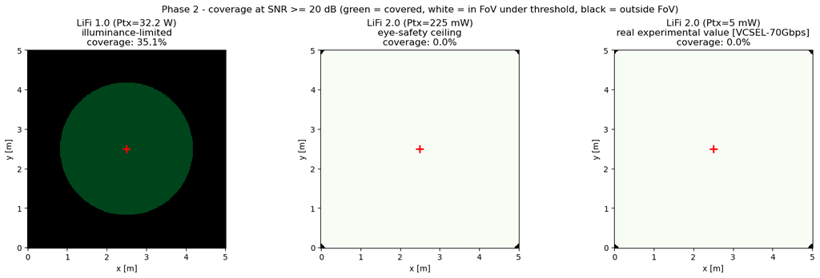

```python
_, _, SNR_led_re, SNR_vcsel_eyesafe, _, R_vcsel_eyesafe = snr_rate(PTX_LED_REALISTIC, PTX_VCSEL_EYESAFE)
_, _, _, SNR_vcsel_exp, _, R_vcsel_exp = snr_rate(PTX_LED_REALISTIC, PTX_VCSEL_EXPERIMENTAL)

GAMMA_TH_DB = 20.0  # SNR threshold used to define "covered" [dB]
gamma_th = 10**(GAMMA_TH_DB / 10)
cov_led_re = SNR_led_re >= gamma_th # coverage map, LED at realistic power
cov_vcsel_eyesafe_map = SNR_vcsel_eyesafe >= gamma_th # coverage map, VCSEL at the eye-safety ceiling
cov_vcsel_exp_map = SNR_vcsel_exp >= gamma_th  # coverage map, VCSEL at the experimental power

cov_cmap = plt.cm.Greens.copy()
cov_cmap.set_bad("black")
in_fov_led = theta <= FOV      # LED FoV mask
in_fov_vcsel = theta <= theta_r  # VCSEL FoV mask

def cov_black_outside(cov, in_fov):
    return np.where(in_fov, cov.astype(float), np.nan)

fig, axes = plt.subplots(1, 3, figsize=(15.5, 4.8), constrained_layout=True)
panels = [
    (cov_black_outside(cov_led_re, in_fov_led), cov_led_re,
     f"LiFi 1.0 (Ptx={PTX_LED_REALISTIC:.1f} W)\nilluminance-limited"),
    (cov_black_outside(cov_vcsel_eyesafe_map, in_fov_vcsel), cov_vcsel_eyesafe_map,
     f"LiFi 2.0 (Ptx={PTX_VCSEL_EYESAFE*1e3:.0f} mW)\neye-safety ceiling"),
    (cov_black_outside(cov_vcsel_exp_map, in_fov_vcsel), cov_vcsel_exp_map,
     f"LiFi 2.0 (Ptx={PTX_VCSEL_EXPERIMENTAL*1e3:.0f} mW)\nreal experimental value [VCSEL-70Gbps]"),
]
for ax, (cov_disp, cov_bool, title) in zip(axes, panels):
    ax.pcolormesh(X, Y, cov_disp, shading="auto", cmap=cov_cmap, vmin=0, vmax=1)
    ax.plot(*TX_POS[:2], "r+", markersize=10, mew=2)
    ax.set_title(f"{title}\ncoverage: {100*cov_bool.mean():.1f}%")
    ax.set_xlabel("x [m]")
    ax.set_ylabel("y [m]")
    ax.set_aspect("equal")
fig.suptitle(f"Phase 2 - coverage at SNR >= {GAMMA_TH_DB:.0f} dB "
             "(green = covered, white = in FoV under threshold, black = outside FoV)")
plt.show()
```

Taking into account realistic power levels for each technology, the single LED covers roughly a third of the room, while the single VCSEL barely covers anything, either using the theoretical eye-safety ceiling or the much lower experimental value.

### Summary table and energy efficiency

```python
import pandas as pd

R_led_re = 0.5 * B1 * np.log2(1 + K_BOUND * SNR_led_re)  # rate map at realistic LED power (not kept by the cell above)

def ee_peak_avg(rate_map, Ptx):
    # (peak, avg) energy efficiency in bit/J, from a rate map [bit/s] and Ptx [W]
    peak = np.nanmax(rate_map) / Ptx
    avg = np.nanmean(np.nan_to_num(rate_map, nan=0.0)) / Ptx
    return peak, avg

rows = []
def add_row(name, Ptx, SNR_map, R_map, cov_frac):
    ee_peak, ee_avg = ee_peak_avg(R_map, Ptx)
    rows.append({
        "Scenario": name,
        "Ptx": f"{Ptx:.4g} W",
        "Peak SNR [dB]": round(10 * np.log10(np.nanmax(SNR_map)), 1),
        "Peak rate [Mbit/s]": round(np.nanmax(R_map) / 1e6, 1),
        f"Coverage@{GAMMA_TH_DB:.0f}dB [%]": round(100 * cov_frac, 1),
        "EE peak [Mbit/J]": round(ee_peak / 1e6, 2),
        "EE avg [Mbit/J]": round(ee_avg / 1e6, 4),
    })

add_row("LiFi 1.0 (Phase 1, norm. 1 W)",     PTX_NORM,               SNR_led1,          R_led1,          np.mean(SNR_led1 >= gamma_th))
add_row("LiFi 2.0 (Phase 1, norm. 1 W)",     PTX_NORM,               SNR_vcsel1,        R_vcsel1,        np.mean(SNR_vcsel1 >= gamma_th))
add_row("LiFi 1.0 (Phase 2, realistic)",     PTX_LED_REALISTIC,      SNR_led_re,        R_led_re,        cov_led_re.mean())
add_row("LiFi 2.0 (Phase 2, eye-safety)",    PTX_VCSEL_EYESAFE,      SNR_vcsel_eyesafe, R_vcsel_eyesafe, cov_vcsel_eyesafe_map.mean())
add_row("LiFi 2.0 (Phase 2, experimental)",  PTX_VCSEL_EXPERIMENTAL, SNR_vcsel_exp,     R_vcsel_exp,     cov_vcsel_exp_map.mean())

summary_df = pd.DataFrame(rows)
summary_df
```

|  | Scenario | Ptx | Peak SNR [dB] | Peak rate [Mbit/s] | Coverage@20dB [%] | EE peak [Mbit/J] | EE avg [Mbit/J] |
| --- | --- | --- | --- | --- | --- | --- | --- |
| 0 | LiFi 1.0 (Phase 1, norm. 1 W) | 1 W | 17.9 | 47.9 | 0.0 | 47.91 | 12.1975 |
| 1 | LiFi 2.0 (Phase 1, norm. 1 W) | 1 W | 23.5 | 6610.3 | 4.0 | 6610.26 | 1211.6398 |
| 2 | LiFi 1.0 (Phase 2, realistic) | 32.15 W | 48.0 | 147.5 | 35.1 | 4.59 | 1.4568 |
| 3 | LiFi 2.0 (Phase 2, eye-safety) | 0.2249 W | 10.5 | 2558.7 | 0.0 | 11376.16 | 1038.1370 |
| 4 | LiFi 2.0 (Phase 2, experimental) | 0.005 W | -22.5 | 3.5 | 0.0 | 696.69 | 39.1907 |

### Spectral consideration: wavelength-dependent responsivity

Everywhere above both technologies use the same fixed responsivity $\rho = 1$ A/W, which is what isolates the channel and power effects. In reality the photodiode responsivity depends on the wavelength,

$$\rho(\lambda) = \eta\,\frac{q\,\lambda}{h\,c},$$

and for a silicon photodiode it grows with $\lambda$ up to the ~1100 nm cut-off. LiFi 1.0 emits across the visible band, while LiFi 2.0 emits in the near-IR (~950 nm), so at the same received optical power the VCSEL produces more photocurrent, thus the near-IR link is beneficiating the receiver.

This is a receiver property, so it does not change any Phase 1/2 conclusion, but since $\text{SNR}\propto(\rho P_r)^2$ it does shift the SNR. I keep $\rho = 1$ as the baseline and only quantify the effect here with representative datasheet values.

```python
Q_E = 1.602e-19    # electron charge [C]
H_PLANCK = 6.626e-34  # Planck constant [J*s]
C_LIGHT = 3e8      # speed of light [m/s]

def responsivity_ideal(lam_nm, eta=1.0):
    # ideal photodiode responsivity rho = eta*q*lambda/(h*c) [A/W]
    lam = lam_nm * 1e-9
    return eta * Q_E * lam / (H_PLANCK * C_LIGHT)

# representative silicon PIN photodiode values (datasheet-dependent)
RHO_LED = 0.4    # ~550 nm effective, visible band (LiFi 1.0) [A/W]
RHO_VCSEL = 0.6  # ~950 nm (LiFi 2.0) [A/W]

print(f"ideal rho (eta=1): @550nm = {responsivity_ideal(550):.2f} A/W, @950nm = {responsivity_ideal(950):.2f} A/W")
print(f"representative rho: LED (visible) = {RHO_LED} A/W, VCSEL (950 nm) = {RHO_VCSEL} A/W")

# effect on SNR: SNR ~ (rho*Pr)^2
d_snr_led_dB = 20 * np.log10(RHO_LED / RHO)
d_snr_vcsel_dB = 20 * np.log10(RHO_VCSEL / RHO)
print(f"\nSNR shift vs the rho=1 baseline: LED {d_snr_led_dB:+.1f} dB, VCSEL {d_snr_vcsel_dB:+.1f} dB")
print(f"Net relative shift in favour of the VCSEL: {d_snr_vcsel_dB - d_snr_led_dB:+.1f} dB")

# recompute Phase 2 coverage with the wavelength-dependent responsivities (same [RIS-VLC] eq. (12) SNR)
SNR_led_rho = (RHO_LED * PTX_LED_REALISTIC * H_led)**2 / (N0 * B1)
SNR_vcsel_rho = (RHO_VCSEL * PTX_VCSEL_EYESAFE * H_vcsel)**2 / (N0 * B2)
print(f"\nPhase 2 coverage @ {GAMMA_TH_DB:.0f} dB with wavelength-dependent rho:")
print(f"  LiFi 1.0 (rho={RHO_LED}):   {100*np.mean(SNR_led_rho >= gamma_th):.1f}%  (was {100*cov_led_re.mean():.1f}% at rho=1)")
print(f"  LiFi 2.0 (rho={RHO_VCSEL}): {100*np.mean(SNR_vcsel_rho >= gamma_th):.1f}%  (was {100*cov_vcsel_eyesafe_map.mean():.1f}% at rho=1)")
print("\n-> the +3.5 dB relative gain for the VCSEL doesn't flip the picture: a single VCSEL is still power-limited.")
```

```
ideal rho (eta=1): @550nm = 0.44 A/W, @950nm = 0.77 A/W
representative rho: LED (visible) = 0.4 A/W, VCSEL (950 nm) = 0.6 A/W

SNR shift vs the rho=1 baseline: LED -8.0 dB, VCSEL -4.4 dB
Net relative shift in favour of the VCSEL: +3.5 dB

Phase 2 coverage @ 20 dB with wavelength-dependent rho:
  LiFi 1.0 (rho=0.4):   35.1%  (was 35.1% at rho=1)
  LiFi 2.0 (rho=0.6): 0.0%  (was 0.0% at rho=1)

-> the +3.5 dB relative gain for the VCSEL doesn't flip the picture: a single VCSEL is still power-limited.
```

## Interpretation

In Phase 1, since both transmitters used the same power, we could compare the channel models directly, and the VCSEL came out ahead near the beam axis just because it concentrates power more tightly.

Once we consider realistic powers, everything comes down to how much optical power each transmitter is actually allowed to emit. An LED can put out the watts needed for room illumination without any issue; a single VCSEL is stuck in the milliwatt range because of eye-safety limits.

### From a single VCSEL to an array

A single VCSEL does not provide sufficient room-scale coverage under realistic operating conditions. This naturally raises the question of whether that limitation can be overcome not by pushing more power out of one emitter, but by combining several low-power VCSELs instead, which is the direction `[VCSEL-Precoding]`'s array architecture actually takes.

## Scaling analysis: equivalent optical power from multiple VCSELs

Here we keep the same Tx position, the same room, and the same receiver and SNR threshold as in Phase 2, and bundle $N$ VCSELs together at that single point, adding up their optical power directly (VCSELs from different emitters aren't mutually coherent, so intensities add rather than fields).

Those aspects should be addressed in the multi-cell analysis.

The question here is just: if we had $N$ eye-safe VCSELs and stacked them all at the same point, how far would that get us?

I sweep $N$ over powers of two, from 1 up to 64, for both VCSEL power anchors used in Phase 2.

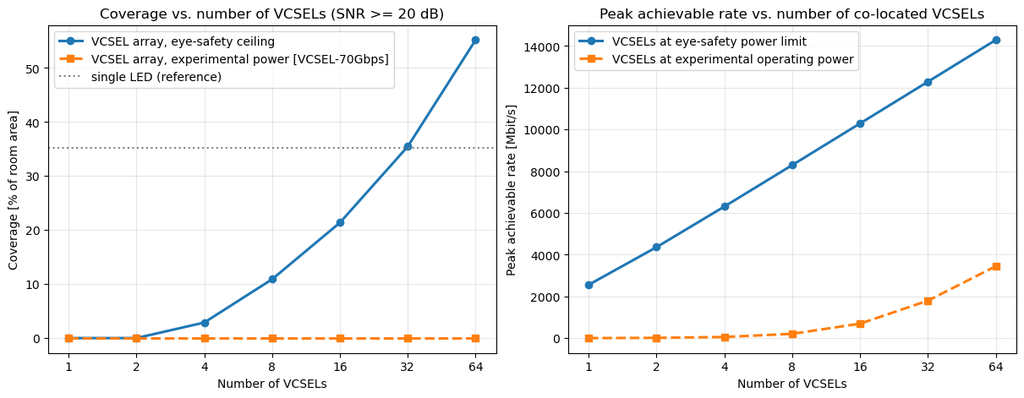

```python
N_VCSEL_LIST = [1, 2, 4, 8, 16, 32, 64]  # how many VCSELs are bundled at the same tx point

cov_vs_N_eyesafe, cov_vs_N_exp = [], []  # coverage [%] for each N, one list per power anchor
peak_rate_vs_N_eyesafe, peak_rate_vs_N_exp = [], [] # peak achievable rate [Mbit/s] for each N

for n in N_VCSEL_LIST:
    Ptx_eyesafe_total = n * PTX_VCSEL_EYESAFE  # total optical power of the n-VCSEL bundle, eye-safety anchor
    Ptx_exp_total = n * PTX_VCSEL_EXPERIMENTAL # total optical power of the n-VCSEL bundle, experimental anchor
    _, _, _, SNR_n_eyesafe, _, R_n_eyesafe = snr_rate(PTX_LED_REALISTIC, Ptx_eyesafe_total)
    _, _, _, SNR_n_exp, _, R_n_exp = snr_rate(PTX_LED_REALISTIC, Ptx_exp_total)
    cov_vs_N_eyesafe.append(100 * np.mean(SNR_n_eyesafe >= gamma_th))
    cov_vs_N_exp.append(100 * np.mean(SNR_n_exp >= gamma_th))
    peak_rate_vs_N_eyesafe.append(np.nanmax(R_n_eyesafe) / 1e6)
    peak_rate_vs_N_exp.append(np.nanmax(R_n_exp) / 1e6)

cov_led_value = 100 * cov_led_re.mean()  # single-LED coverage from Phase 2, as a reference line

fig, axes = plt.subplots(1, 2, figsize=(12, 4.6), constrained_layout=True)

ax = axes[0]
ax.plot(N_VCSEL_LIST, cov_vs_N_eyesafe, "o-", lw=2.2, label="VCSEL array, eye-safety ceiling")
ax.plot(N_VCSEL_LIST, cov_vs_N_exp, "s--", lw=2.2, label="VCSEL array, experimental power [VCSEL-70Gbps]")
ax.axhline(cov_led_value, color="gray", ls=":", lw=1.5, label="single LED (reference)")
ax.set_xscale("log", base=2)
ax.set_xticks(N_VCSEL_LIST)
ax.set_xticklabels(N_VCSEL_LIST)
ax.set_xlabel("Number of VCSELs")
ax.set_ylabel("Coverage [% of room area]")
ax.set_title(f"Coverage vs. number of VCSELs (SNR >= {GAMMA_TH_DB:.0f} dB)")
ax.legend()
ax.grid(alpha=.3)

ax = axes[1]
ax.plot(N_VCSEL_LIST, peak_rate_vs_N_eyesafe, "o-", lw=2.2, label="VCSELs at eye-safety power limit")
ax.plot(N_VCSEL_LIST, peak_rate_vs_N_exp, "s--", lw=2.2, label="VCSELs at experimental operating power")
ax.set_xscale("log", base=2)
ax.set_xticks(N_VCSEL_LIST)
ax.set_xticklabels(N_VCSEL_LIST)
ax.set_xlabel("Number of VCSELs")
ax.set_ylabel("Peak achievable rate [Mbit/s]")
ax.set_title("Peak achievable rate vs. number of co-located VCSELs")
ax.legend()
ax.grid(alpha=.3)

plt.show()
```

```python
scaling_df = pd.DataFrame({
    "N": N_VCSEL_LIST,
    "Ptx_total eye-safety [W]": [round(n * PTX_VCSEL_EYESAFE, 3) for n in N_VCSEL_LIST],
    "Coverage eye-safety [%]": [round(c, 1) for c in cov_vs_N_eyesafe],
    "Ptx_total experimental [W]": [round(n * PTX_VCSEL_EXPERIMENTAL, 4) for n in N_VCSEL_LIST],
    "Coverage experimental [%]": [round(c, 1) for c in cov_vs_N_exp],
})
print(f"Reference: single LED coverage @ {GAMMA_TH_DB:.0f} dB = {cov_led_value:.1f}%")
print("chosen as a representative mid-range value; Phase 1 already showed the full sweep")
scaling_df
```

```
Reference: single LED coverage @ 20 dB = 35.1%
chosen as a representative mid-range value; Phase 1 already showed the full sweep
```

|  | N | Ptx_total eye-safety [W] | Coverage eye-safety [%] | Ptx_total experimental [W] | Coverage experimental [%] |
| --- | --- | --- | --- | --- | --- |
| 0 | 1 | 0.225 | 0.0 | 0.005 | 0.0 |
| 1 | 2 | 0.450 | 0.0 | 0.010 | 0.0 |
| 2 | 4 | 0.900 | 2.9 | 0.020 | 0.0 |
| 3 | 8 | 1.799 | 10.9 | 0.040 | 0.0 |
| 4 | 16 | 3.599 | 21.4 | 0.080 | 0.0 |
| 5 | 32 | 7.197 | 35.5 | 0.160 | 0.0 |
| 6 | 64 | 14.395 | 55.2 | 0.320 | 0.0 |

## Transition to the multi-cell analysis

Bundling every VCSEL at the same point isn't a realistic array though. It only produces a single bright spot instead of uniform coverage, it can't serve more than one user at a time since every element points at the same place, and packing that many lasers together may no longer be eye-safe as a bundle.

This is exactly the gap from `[VCSEL-Precoding]`: an array distributed over the ceiling, precoded so that different (possibly overlapping) subsets of elements serve different users at once, instead of every element aiming at the same spot.

The next stage moves from this single-transmitter analysis to a multi-cell one, to see what a spatially distributed, precoded array actually achieves for coverage uniformity and multi-user capacity, not just for raw single-point power.